# PSTAT 131 Final Project

Lance Sanchez

2025-06-13

# Predicting Song Genre

## Using machine learning models and Spotify data to classify a song into a certain genre giving certain sonical features

### UCSB Spring 2025

# Table of Contents:

### 1. Introduction

### 2. Data Citation

### 3. Exploratory Data Analysis

### 4. Data Splitting and Cross-Validation

### 5. Model Fitting

### 6. Model Selection and Performance

### 7. Conclusion

# 1. Introduction:

This project focuses on building a classification model that uses Spotify data to predict the genre of a song. A classification model is a type of machine learning algorithm designed to categorize data into predefined groups or labels—in this case, music genres such as pop, rock, hip-hop, and jazz. The dataset contains various audio features provided by Spotify, such as tempo, energy, danceability, and acousticness, which quantify different aspects of a song’s sound. These features serve as input variables, or predictors, that the model analyzes to determine the most likely genre for a given track. Understanding and processing these numerical features effectively is crucial to training a model that can make accurate genre predictions.

[Eminem Cicirinella GIF](https://tenor.com/view/eminem-cicirinella-che-teneva-gif-24132633)from [Eminem GIFs](https://tenor.com/search/eminem-gifs)

The primary goal of this project is to explore the relationship between a song’s audio characteristics and its genre label, and to use this insight to construct a reliable predictive model. By evaluating the model’s performance on a test dataset, we can assess how well it generalizes to new, unseen songs. The project also highlights the value of data preprocessing, feature selection, and algorithm tuning in machine learning workflows. Beyond building an accurate model, another objective is to interpret which audio features are most influential in genre classification, potentially revealing patterns in how different types of music are structured. This has practical applications in music recommendation systems, playlist generation, and automated music tagging.

# 2. Data Citation:

The Spotify Tracks Genre Dataset, compiled by the Kaggle user “TheDevastator” in 2021, is a robust collection of audio and metadata information derived from Spotify’s Web API using Python scripting. This dataset is hosted on the Kaggle platform and offers an extensive representation of musical diversity by including tracks across 125 distinct genres. It is particularly valuable for data analysis and machine learning projects centered around music classification, trend identification, and predictive modeling.

The dataset features more than 20 well-structured columns that capture both general metadata and advanced audio features. Key metadata columns include artists, identifying the performers or groups behind each track, and album_name, which situates the track within its album context. The track_name serves as a unique identifier, while the popularity column—ranging from 0 to 100—quantifies how widely a track is appreciated by Spotify users. The duration_ms column indicates the track’s length in milliseconds, providing insights into average durations across genres. The explicit column flags whether a song contains explicit content, enabling content-related analysis across genres or over time.

The dataset’s rich array of audio features is sourced from Spotify’s proprietary algorithms. These include danceability, which measures how suitable a track is for dancing based on beat regularity and rhythm strength; energy, which captures the track’s intensity; and key, indicating the musical key using an integer representation (e.g., 0 = C, 1 = C#/Db). Additional features like loudness (measured in decibels), mode (major or minor), and speechiness (presence of spoken words) support detailed musical profiling. Other noteworthy features include acousticness, which estimates the acoustic nature of a track; instrumentalness, indicating the likelihood of a track being instrumental; liveness, measuring the presence of live audience sounds; valence, reflecting the emotional positivity of a song; tempo, indicating beats per minute (BPM); and time_signature, which identifies the rhythmic structure.

[Shake It Shake Itzy GIF](https://tenor.com/view/shake-it-shake-itzy-cake-itzy-cake-kpop-gif-4054113887102447591)from [Shake It Shake GIFs](https://tenor.com/search/shake+it+shake-gifs)

Overall, this dataset is well-suited for researchers, data scientists, music theorists, and enthusiasts seeking to explore the complex relationships within music. It can be applied in various domains such as genre prediction, popularity forecasting, and emotional analysis of tracks. The dataset enables users to combine quantitative music features with qualitative insights, making it a valuable tool for both technical and artistic exploration.

## Link to Dataset:

https://www.kaggle.com/datasets/thedevastator/spotify-tracks-genre-dataset

# 3. Exploratory Data Analysis:

```r
library(janitor)
library(readr)

song_raw <- read_csv("train.csv")

# Clean column names using janitor
song_clean <- clean_names(song_raw)

head(song_clean)
```

```
## # A tibble: 6 × 21
##   unnamed_0 track_id        artists album_name track_name popularity duration_ms
##       <dbl> <chr>           <chr>   <chr>      <chr>           <dbl>       <dbl>
## 1         0 5SuOikwiRyPMVo… Gen Ho… Comedy     Comedy             73      230666
## 2         1 4qPNDBW1i3p13q… Ben Wo… Ghost (Ac… Ghost - A…         55      149610
## 3         2 1iJBSr7s7jYXzM… Ingrid… To Begin … To Begin …         57      210826
## 4         3 6lfxq3CG4xtTiE… Kina G… Crazy Ric… Can't Hel…         71      201933
## 5         4 5vjLSffimiIP26… Chord … Hold On    Hold On            82      198853
## 6         5 01MVOl9KtVTNfF… Tyrone… Days I Wi… Days I Wi…         58      214240
## # ℹ 14 more variables: explicit <lgl>, danceability <dbl>, energy <dbl>,
## #   key <dbl>, loudness <dbl>, mode <dbl>, speechiness <dbl>,
## #   acousticness <dbl>, instrumentalness <dbl>, liveness <dbl>, valence <dbl>,
## #   tempo <dbl>, time_signature <dbl>, track_genre <chr>
```

Next, let’s clean the data using dplyr. Begin by removing unnecessary columns like unnamed_0, track_id, artists, album_name, and track_name. These are either identifiers or text-heavy fields that aren’t useful for predicting genre. Then, filter the dataset to keep only songs with a popularity score over 70. This focuses your analysis on more popular tracks that are likely to have better-defined characteristics. To handle class imbalance, group the data by track_genre, filter for genres with at least 100 tracks, and randomly sample 100 songs from each group. This ensures each genre has an equal number of samples, which helps prevent your model from being biased toward more common genres.

```r
library(dplyr)
library(forcats)

song_clean <- song_clean %>%
  # Remove unwanted columns
  select(-unnamed_0, -track_id, -artists, -album_name, -track_name) %>%

  # Filter for songs with popularity over 70
  filter(popularity > 70) %>%

  # Only keep genres with at least 100 songs, then sample 100 from each
  group_by(track_genre) %>%
  filter(n() >= 100) %>%
  slice_sample(n = 100) %>%
  ungroup()
```

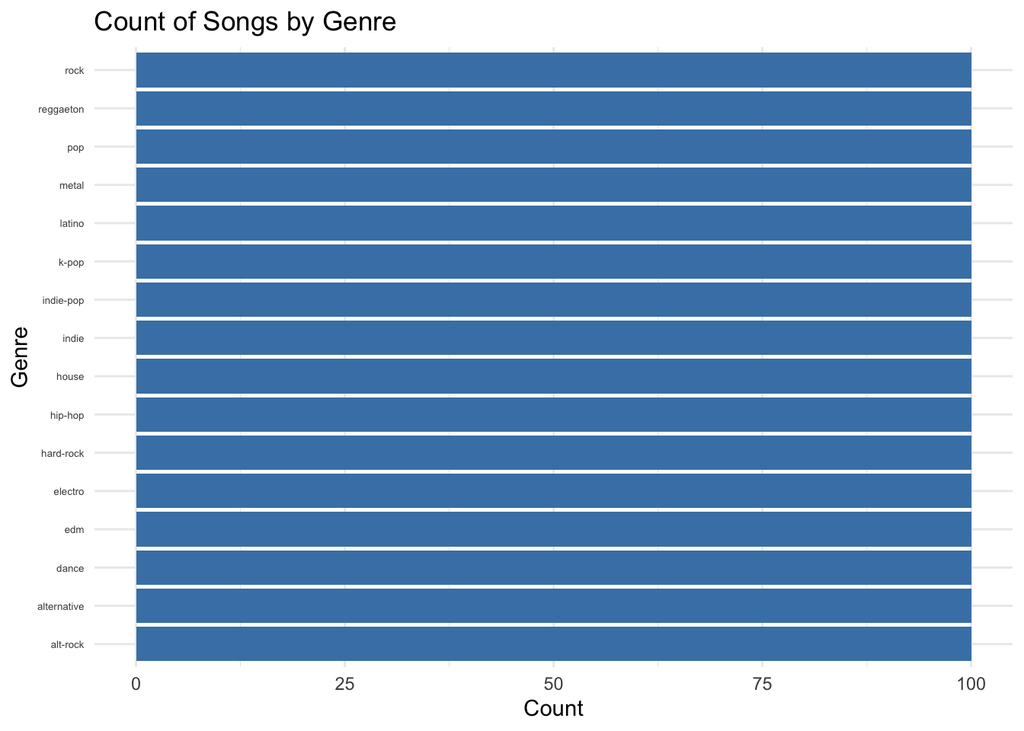

```r
library(ggplot2)

# Create bar chart with flipped coordinates for better readability
ggplot(song_clean, aes(x = fct_infreq(track_genre))) +  # reorder by frequency
  geom_bar(fill = "steelblue") +
  theme_minimal() +
  labs(title = "Count of Songs by Genre", x = "Genre", y = "Count") +
  coord_flip() +  # flip x and y axes
  theme(axis.text.y = element_text(size = 5))
```

# 4. Data Splitting and Cross-Validation

With the dataset cleaned and balanced, it’s time to prepare for modeling. First, filter out any rows with missing track_genre values, and convert both track_genre and explicit to factor variables so they’re treated correctly in your model. Then, use initial_split() from the rsample package to split the data into training and testing sets, stratifying by genre to maintain balance. Don’t forget to set a random seed for reproducibility. To further validate your model, set up 5-fold cross-validation using vfold_cv() and stratify by genre again. This helps you evaluate model performance more reliably and tune hyperparameters without overfitting.

```r
song_clean <- song_clean %>%
  filter(!is.na(track_genre)) %>%
  mutate(
    track_genre = factor(track_genre),
    explicit = factor(explicit)
  )

library(rsample)

set.seed(123)
song_split <- initial_split(song_clean, prop = 0.75, strata = track_genre)
train_data <- training(song_split)
test_data  <- testing(song_split)

# Perform 5-fold cross-validation, stratified by track_genre
music_folds <- vfold_cv(train_data, v = 5, strata = track_genre)

music_folds
```

```
## #  5-fold cross-validation using stratification
## # A tibble: 5 × 2
##   splits            id
##   <list>            <chr>
## 1 <split [960/240]> Fold1
## 2 <split [960/240]> Fold2
## 3 <split [960/240]> Fold3
## 4 <split [960/240]> Fold4
## 5 <split [960/240]> Fold5
```

To better understand the relationships between your numeric predictors, calculate a correlation matrix and visualize it using corrplot. Select only the numeric columns, compute the correlations, and then plot the upper triangle with colored squares. Adjust the label sizes to make the plot easy to read. This step can help you spot multicollinearity or identify features that might be redundant.

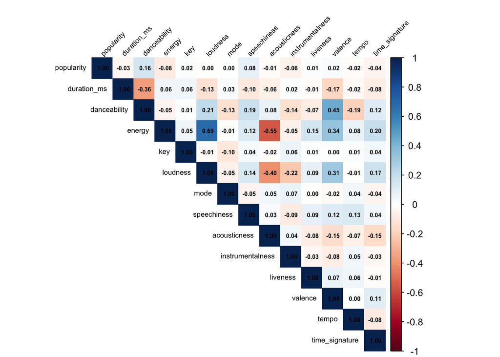

```r
library(corrplot)

# Select only numeric variables from the training set
song_numeric <- train_data %>%
  select(where(is.numeric))

# Compute correlation matrix
cor_matrix <- cor(song_numeric, use = "complete.obs")

# Create the correlation plot
corrplot(cor_matrix,
         method = "color",     # use colored squares
         type = "upper",       # only upper triangle
         tl.col = "black",     # text color
         tl.srt = 45,          # rotate axis labels
         addCoef.col = "black",# show correlation values
         number.cex = 0.5,     # shrink correlation number size
         tl.cex = 0.6,         # shrink axis label size
         mar = c(0, 0, 1, 0))  # reduce margins
```

Finally, let’s build a preprocessing pipeline using the recipes package. Specify track_genre as the target and include all other columns as predictors. Use step_dummy() to convert categorical variables into dummy variables, and then apply step_center() and step_scale() to standardize the numeric features. This ensures all predictors are on the same scale, which is crucial for models like Elastic Net. With this preprocessing pipeline in place, your data is now ready for training and evaluation.

```r
library(recipes)

# Create recipe using cleaned data
music_recipe <- recipe(track_genre ~ ., data = song_clean) %>%
  step_dummy(all_nominal_predictors()) %>%
  step_center(all_predictors()) %>%
  step_scale(all_predictors())

music_recipe
```

[output not shown]

# 5. Model Fitting:

Let’s now build an Elastic Net classifier to predict the track genre. Start by defining a model specification using multinom_reg() from the parsnip package, and set both penalty and mixture to tune() so we can optimize them during cross-validation. We’ll use glmnet as the engine and set the mode to classification since we’re predicting categories. Then, let’s create a workflow that combines this model with the preprocessing recipe we built earlier. To tune the model, let’s generate a regular grid using grid_regular() to explore combinations of penalty strengths and mixing parameters. This helps us find the best balance between L1 and L2 regularization.

```r
library(tidymodels)

# Set up elastic net model with tunable penalty and mixture
elastic_net_model <- multinom_reg(
  mode = "classification",
  penalty = tune(),   # regularization strength
  mixture = tune()    # balance between L1 (lasso) and L2 (ridge)
) %>%
  set_engine("glmnet")

# Create workflow with recipe
music_workflow <- workflow() %>%
  add_model(elastic_net_model) %>%
  add_recipe(music_recipe)

# Create regular grid for tuning
elastic_grid <- grid_regular(
  penalty(range = c(0.01, 3)),
  mixture(range = c(0, 1)),
  levels = 10
)
```

Let’s then build a Random Forest classifier to predict the track genre. Begin by specifying the model using rand_forest() from the parsnip package, and set mtry, trees, and min_n to tune() so we can optimize them through cross-validation. We’ll use “ranger” as the engine and specify “classification” as the mode. Next, create a workflow that combines this model with the preprocessing recipe we’ve already defined. To tune the model, define a regular grid using grid_regular() that explores different values for the number of variables tried at each split (mtry), the total number of trees, and the minimum number of observations required in a node. This setup helps us identify the most effective hyperparameter combination for our classification task.

```r
library(tidymodels)

# Set up random forest model with tunable hyperparameters
rf_model <- rand_forest(
  mode = "classification",
  mtry = tune(),     # num variables considered at each split
  trees = tune(),    # num trees in forest
  min_n = tune()     # min num of observations in a node
) %>%
  set_engine("ranger", importance = "impurity")

# Create workflow with recipe
rf_workflow <- workflow() %>%
  add_model(rf_model) %>%
  add_recipe(music_recipe)

# Define regular tuning grid
rf_grid <- grid_regular(
  mtry(range = c(1, 15)),
  trees(range = c(100, 1000)),
  min_n(range = c(2, 20)),
  levels = 8
)
```

Once we’ve saved our tuning results for both the Elastic Net and Random Forest models, let’s read them back into the environment using readRDS(). Then, let’s visualize the performance of each model across the tuning grid with autoplot(), which gives us a sense of how each parameter combination performed in terms of ROC AUC.

Elastic Net:

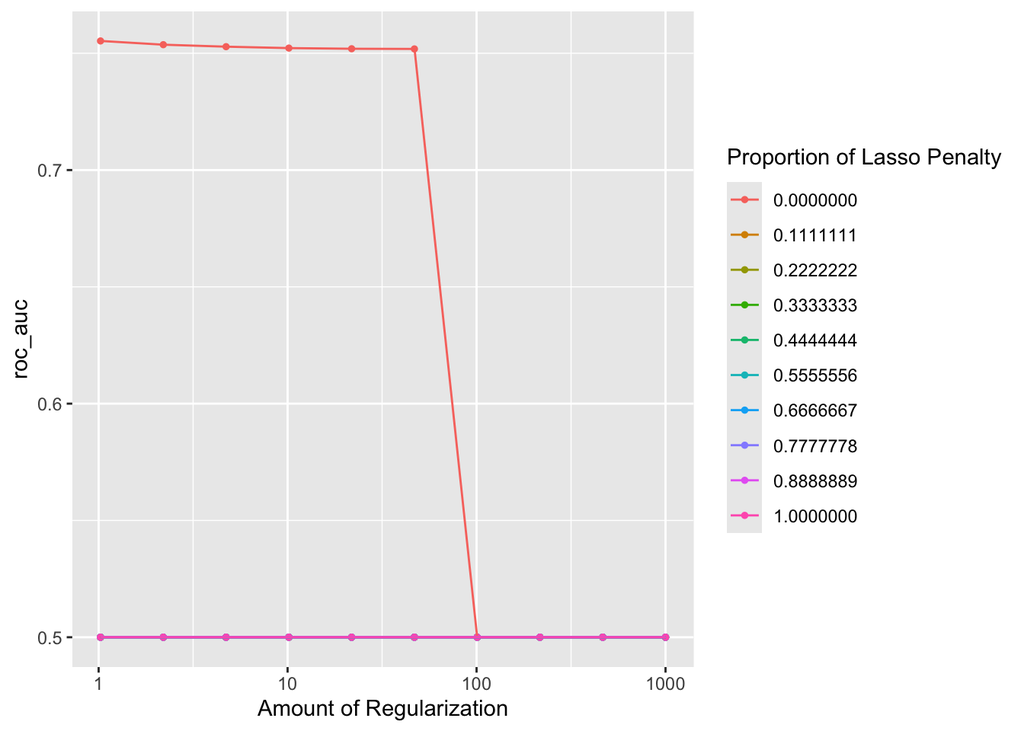

```r
# Tune elastic net model on cross-validation folds (Commented out to reduce writing time)
#set.seed(123)
#elastic_results <- tune_grid(
#  music_workflow,
#  resamples = music_folds,
#  grid = elastic_grid,
#  metrics = metric_set(roc_auc))

# Save results
#saveRDS(elastic_results, "elastic_results.rds")

# Read the RDS file and assign it to an object
elastic_results <- readRDS("elastic_results.rds")

# Visualize performance
autoplot(elastic_results)
```

Random Forest:

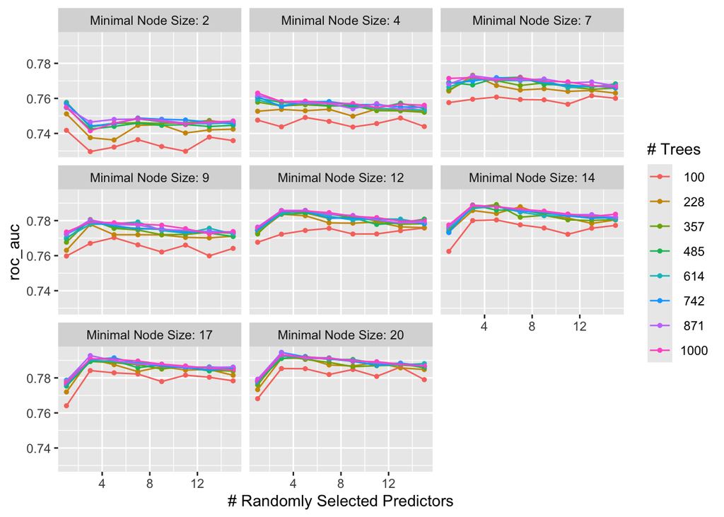

```r
#library(ranger)

# Tune random forest model on cross-validation folds (Commented out to reduce writing time)
#set.seed(123)
#rf_results <- tune_grid(
#  rf_workflow,
#  resamples = music_folds,
#  grid = rf_grid,
#  metrics = metric_set(roc_auc))

# Save results
#saveRDS(rf_results, "rf_results.rds")

# Read the RDS file and assign it to an object
rf_results <- readRDS("rf_results.rds")

# Visualize performance
autoplot(rf_results)
```

# 6. Model Selection and Performance:

After saving the tuning results using saveRDS(), load them back with readRDS() and visualize model performance across parameter combinations using autoplot(). Use show_best() to extract top-performing configurations for both models based on ROC AUC.

Finalize the best-performing Random Forest model using select_best() and finalize_model(). Fit the finalized workflow to the training data.

To evaluate the final model on the test set, generate class probabilities and predicted labels. Use roc_curve() and autoplot() to plot ROC curves for each class. Generate a confusion matrix using conf_mat() and autoplot() to visualize model accuracy and errors.

```r
# Best elastic net model
show_best(elastic_results, metric = "roc_auc")
```

```
## # A tibble: 5 × 8
##   penalty mixture .metric .estimator  mean     n std_err .config
##     <dbl>   <dbl> <chr>   <chr>      <dbl> <int>   <dbl> <chr>
## 1    1.02       0 roc_auc hand_till  0.755     5 0.00461 Preprocessor1_Model001
## 2    2.20       0 roc_auc hand_till  0.754     5 0.00464 Preprocessor1_Model002
## 3    4.73       0 roc_auc hand_till  0.753     5 0.00460 Preprocessor1_Model003
## 4   10.2        0 roc_auc hand_till  0.752     5 0.00464 Preprocessor1_Model004
## 5   21.8        0 roc_auc hand_till  0.752     5 0.00462 Preprocessor1_Model005
```

```r
# Best random forest model
show_best(rf_results, metric = "roc_auc")
```

```
## # A tibble: 5 × 9
##    mtry trees min_n .metric .estimator  mean     n std_err .config
##   <int> <int> <int> <chr>   <chr>      <dbl> <int>   <dbl> <chr>
## 1     3   742    20 roc_auc hand_till  0.795     5 0.00679 Preprocessor1_Model4…
## 2     3   871    20 roc_auc hand_till  0.794     5 0.00685 Preprocessor1_Model4…
## 3     3  1000    20 roc_auc hand_till  0.793     5 0.00726 Preprocessor1_Model5…
## 4     3   357    20 roc_auc hand_till  0.793     5 0.00656 Preprocessor1_Model4…
## 5     3   871    17 roc_auc hand_till  0.793     5 0.00745 Preprocessor1_Model4…
```

Looking at these results, we can see that Random Forest appears to work better overall than Elastic Net, so let’s proceed with that as we finalize and fit our final model.

```r
# Load best hyperparameters from tuning
best_rf <- select_best(rf_results, metric = "roc_auc")

# Finalize model with best hyperparameters
final_rf_model <- finalize_model(rf_model, best_rf)

# Final workflow with best model
final_rf_workflow <- workflow() %>%
  add_model(final_rf_model) %>%
  add_recipe(music_recipe)

# Fit final model to training data
final_rf_fit <- fit(final_rf_workflow, data = train_data)
```

Let’s now interpret the fitted Random Forest model by visualizing variable importance. Use the extract_fit_parsnip() function to access the trained model and then pass it to the vip() function to plot which features contributed most to the classification.

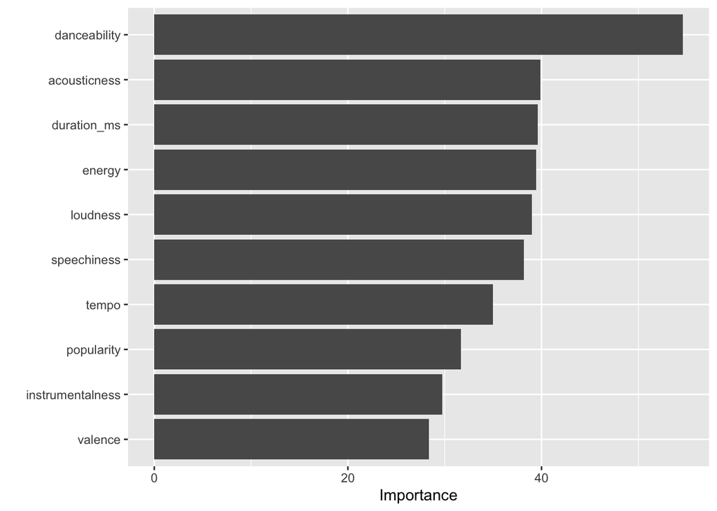

```r
library(vip)

# Extract fitted random forest model
rf_fit_extracted <- extract_fit_parsnip(final_rf_fit)$fit

# Plot variable importance
vip(rf_fit_extracted)
```

To evaluate our model on the test set, let’s generate class probability predictions and predicted labels, then bind these with the actual genre labels from the test data. We’ll extract the appropriate columns and use roc_curve() and autoplot() to visualize ROC curves for each class. Finally, let’s assess classification accuracy using a confusion matrix, visualized as a heatmap with conf_mat() and autoplot(). This gives us a clear picture of how well the model distinguished between track genres.

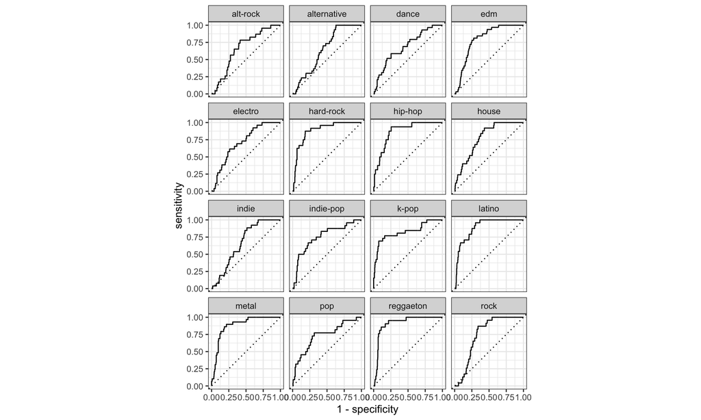

```r
# Make predictions on test set
rf_predictions <- predict(final_rf_fit, test_data, type = "prob") %>%
  bind_cols(predict(final_rf_fit, test_data)) %>%
  bind_cols(test_data %>% select(track_genre))

# Get class labels
class_labels <- levels(test_data$track_genre)

# Build correct column names
pred_cols <- paste0(".pred_", class_labels)

# Generate multiclass ROC curves
rf_predictions %>%
  roc_curve(truth = track_genre, !!!syms(pred_cols)) %>%
  autoplot()
```

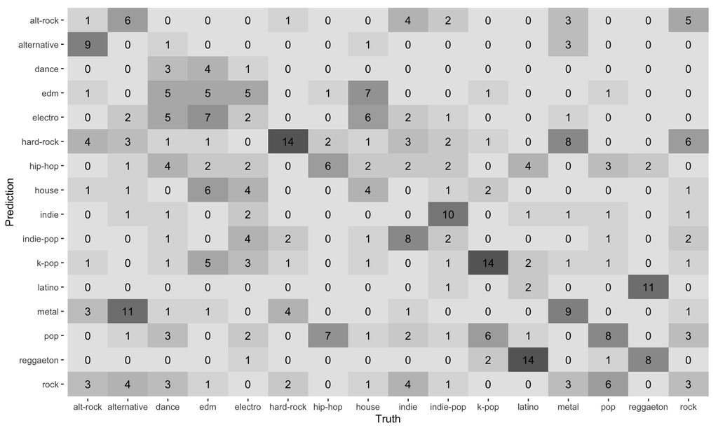

```r
# Confusion matrix and heatmap
rf_predictions %>%
  conf_mat(truth = track_genre, estimate = .pred_class) %>%
  autoplot(type = "heatmap")
```

# 7. Conclusion:

[Thank U Next Ariana GIF](https://tenor.com/view/thank-u-next-ariana-italy-needs-ariana-thank-u-next-perfume-arianaitaly-gif-7683933399502148428)from [Thank U Next GIFs](https://tenor.com/search/thank+u+next-gifs)